# Overall Practice with R Answer Key

Authors

Mary Piper

Meeta Mistry

Radhika Khetani

Will Gammerdinger

Published

December 7, 2025

## Exercises

### Creating vectors/factors and dataframes

1. We are performing RNA-Seq on cancer samples being treated with three different types of treatment (A, B, and P). You have 12 samples total, with 4 replicates per treatment. Write the R code you would use to construct your metadata table as described below.
- Create the vectors/factors for each column (Hint: you can type out each vector/factor, or if you want the process go faster try exploring the `rep()` function).

```r
# Create vectors to use
sex <- c(rep(c("M", "F"),6))
stage <- c(rep(c("I", "II", "II"), 4))
treatment <- c(rep("A", 4), rep("B", 4), rep("P", 4))
myc <- c(2343, 457, 4593, 9035, 3450, 3524, 958, 1053, 8674, 3424, 463, 5105)
```

- Put them together into a dataframe called `meta`.

```r
# Assign vectors to a dataframe
meta <- data.frame(sex, stage, treatment, myc)
```

- Use the `rownames()` function to assign row names to the dataframe (Hint: you can type out the row names as a vector, or if you want the process go faster try exploring the `paste()` function).

```r
# Two ways to add rownames to the dataframe
rownames(meta) <- c("sample1", "sample2", "sample3", "sample4", "sample5", "sample6", "sample7", "sample8", "sample9", "sample10", "sample11", "sample12")
rownames(meta) <- paste("sample", 1:12, sep="")
```

Your finished metadata table should have information for the variables `sex`, `stage`, `treatment`, and `myc` levels:

```r
# Print out meta
meta
```

|  | sex | stage | treatment | myc |
| --- | --- | --- | --- | --- |
| sample1 | M | I | A | 2343 |
| sample2 | F | II | A | 457 |
| sample3 | M | II | A | 4593 |
| sample4 | F | I | A | 9035 |
| sample5 | M | II | B | 3450 |
| sample6 | F | II | B | 3524 |
| sample7 | M | I | B | 958 |
| sample8 | F | II | B | 1053 |
| sample9 | M | II | P | 8674 |
| sample10 | F | I | P | 3424 |

[output cut: 2 more lines]

### Subsetting vectors/factors and dataframes

2. Using the `meta` data frame from question #1, write out the R code you would use to perform the following operations (questions **DO NOT** build upon each other):
- Return only the `treatment` and `sex` columns using `[]`:

```r
# Subset the treatment and sex columns from meta
meta[ , c(1,3)]
```

```
         sex treatment
sample1    M         A
sample2    F         A
sample3    M         A
sample4    F         A
sample5    M         B
sample6    F         B
sample7    M         B
sample8    F         B
sample9    M         P
sample10   F         P
sample11   M         P
sample12   F         P
```

- Return the `treatment` values for samples 5, 7, 9, and 10 using `[]`:

```r
# Subset treatment for samples 5, 7, 9 and 10
meta[c(5,7,9,10), 3]
```

```
[1] "B" "B" "P" "P"
```

- Use `filter()` to return all data for those samples receiving treatment `P`:

```r
# Load tidyverse package
library(tidyverse)

# Filter meta for treatment equal to P
filter(meta, treatment == "P")
```

```
         sex stage treatment  myc
sample9    M    II         P 8674
sample10   F     I         P 3424
sample11   M    II         P  463
sample12   F    II         P 5105
```

- Use `filter()`/`select()` to return only the `stage` and `treatment` data for those samples with `myc` > 5000:

```r
# Filter meta for myc greater than 5000 and select the stage and treatment columns
filter(meta, myc > 5000) %>%
  select(stage, treatment)
```

```
         stage treatment
sample4      I         A
sample9     II         P
sample12    II         P
```

- Remove the `treatment` column from the dataset using `[]`:

```r
# Remove treatment column
meta[, -3]
```

```
         sex stage  myc
sample1    M     I 2343
sample2    F    II  457
sample3    M    II 4593
sample4    F     I 9035
sample5    M    II 3450
sample6    F    II 3524
sample7    M     I  958
sample8    F    II 1053
sample9    M    II 8674
sample10   F     I 3424
sample11   M    II  463
sample12   F    II 5105
```

- Remove samples 7, 8 and 9 from the dataset using `[]`:

```r
# Remove samples 7, 8 and 9 from meta
meta[-7:-9, ]
```

```
         sex stage treatment  myc
sample1    M     I         A 2343
sample2    F    II         A  457
sample3    M    II         A 4593
sample4    F     I         A 9035
sample5    M    II         B 3450
sample6    F    II         B 3524
sample10   F     I         P 3424
sample11   M    II         P  463
sample12   F    II         P 5105
```

- Keep only samples 1-6 using `[]`:

```r
# Subset meta for samples 1 through 6
meta [1:6, ]
```

```
        sex stage treatment  myc
sample1   M     I         A 2343
sample2   F    II         A  457
sample3   M    II         A 4593
sample4   F     I         A 9035
sample5   M    II         B 3450
sample6   F    II         B 3524
```

- Add a column called `pre_treatment` to the beginning of the dataframe with the values T, F, F, F, T, T, F, T, F, F, T, T (Hint: use `cbind()`):

```r
# Create pre_treatment vector
pre_treatment <- c(T, F, F, F, T, T, F, T, F, F, T, T)

# Add pre_treatment column to meta
cbind(pre_treatment, meta)
```

```
         pre_treatment sex stage treatment  myc
sample1           TRUE   M     I         A 2343
sample2          FALSE   F    II         A  457
sample3          FALSE   M    II         A 4593
sample4          FALSE   F     I         A 9035
sample5           TRUE   M    II         B 3450
sample6           TRUE   F    II         B 3524
sample7          FALSE   M     I         B  958
sample8           TRUE   F    II         B 1053
sample9          FALSE   M    II         P 8674
sample10         FALSE   F     I         P 3424
sample11          TRUE   M    II         P  463
sample12          TRUE   F    II         P 5105
```

- Change the names of the columns to: “A”, “B”, “C”, “D”:

```r
# Change the column names of meta
colnames(meta) <- c("A", "B", "C", "D")
```

### Extracting components from lists

3. Create a new list, `list_hw` with three components, the `glengths` vector, the dataframe `df`, and `number` value. Use this list to answer the questions below . `list_hw` has the following structure (NOTE: the components of this list are not currently named):

```
[[1]]
[1]     4.6  3000.0 50000.0

[[2]]
  species glengths
1   ecoli      4.6
2   human   3000.0
3    corn  50000.0

[[3]]
[1] 8
```

```r
# Create list_hw
list_hw <- list(glengths, df, number)

# Print list_hw
list_hw
```

```
[[1]]
[1]     4.6  3000.0 50000.0

[[2]]
  species glengths
1   ecoli      4.6
2   human   3000.0
3    corn  50000.0

[[3]]
[1] 8
```

Write out the R code you would use to perform the following operations (questions **DO NOT** build upon each other):

- Return the second component of the list:

```r
# Subset list_hw for the second item
list_hw[[2]]
```

```
  species glengths
1   ecoli      4.6
2   human   3000.0
3    corn  50000.0
```

- Return `50000.0` from the first component of the list:

```r
# Subset list_hw for the first item and return the third element from the vector
list_hw[[1]][3]
```

```
[1] 50000
```

- Return the value `human` from the second component:

```r
# Subset list_hw for the second item and return the item in the second row and first column
list_hw[[2]][2, 1]
```

```
[1] "human"
```

- Give the components of the list the following names: “genome_lengths”, “genomes”, “record”:

```r
# Create names for list_hw
names(list_hw) <- c("genome_lengths","genomes","record")

# Print list_hw
list_hw
```

```
$genome_lengths
[1]     4.6  3000.0 50000.0

$genomes
  species glengths
1   ecoli      4.6
2   human   3000.0
3    corn  50000.0

$record
[1] 8
```

### Creating figures with ggplot2

Follow the instructions below to build your plot. Write the code you used and provide the final image.

- Read in the metadata file using: `meta <- read.delim("data/Mov10_full_meta.txt", sep="\t", row.names=1)`
- Read in the count matrix file using: `data <- read.delim("data/normalized_counts.txt", sep="\t", row.names=1)`
- Create a vector called `expression` that contains the normalized count values from the row in `data` that corresponds to the `MOV10` gene.

```r
# Read in meta
meta <- read.delim("data/Mov10_full_meta.txt", sep="\t", row.names=1)
# Read in data
data <- read.delim("data/normalized_counts.txt", sep="\t", row.names=1)

# Create vector from MOV10 expression data
expression <- data["MOV10", ]
```

- Check the class of this expression vector. `data.frame`

Then, will need to convert this to a numeric vector using `as.numeric(expression)`

```r
# Show class of expression
class(expression)
```

```
[1] "data.frame"
```

```r
# Convert expression to numeric
expression <- as.numeric(expression)

# Show class of expression again
class(expression)
```

```
[1] "numeric"
```

- Bind that vector to your metadata data frame (`meta`) and call the new data frame `df`.

```r
# Two ways to add expression vector to meta
df <- cbind(meta, expression)
df <- data.frame(meta, expression)
```

- Create a ggplot by constructing the plot line by line:
  - Initialize a ggplot with your `df` as input.
  - Add the `geom_jitter()` geometric object with the required aesthetics
  - Color the points based on `sampletype`
  - Add the `theme_bw()` layer
  - Add the title “Expression of MOV10” to the plot
  - Change the x-axis label to be blank
  - Change the y-axis label to “Normalized counts”
  - Using `theme()` change the following properties of the plot:
    - Remove the legend (Hint: use ?theme help and scroll down to legend.position)
    - Change the plot title size to 1.5x the default and center align
    - Change the axis title to 1.5x the default size
    - Change the size of the axis text only on the y-axis to 1.25x the default size
    - Rotate the x-axis text to 45 degrees using `axis.text.x=element_text(angle=45, hjust=1)`

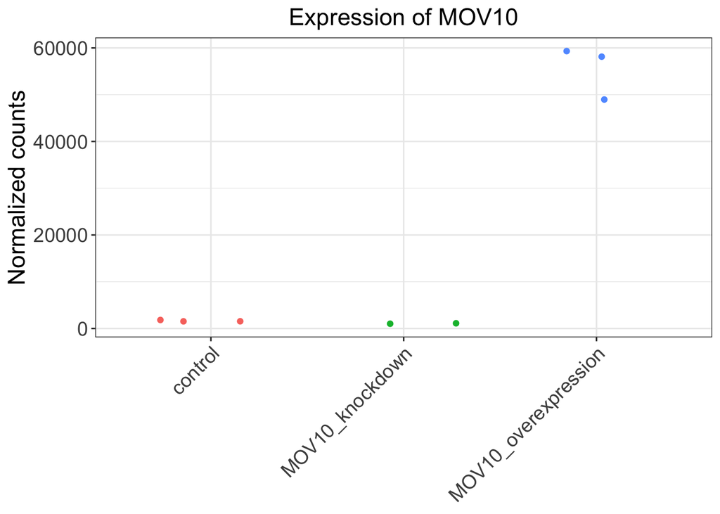

```r
# Create plot
ggplot(df) +
  geom_jitter(aes(x= sampletype, y= expression, color = sampletype)) +
  theme_bw() +
  ggtitle("Expression of MOV10") +
  xlab(NULL) +
  ylab("Normalized counts") +
  theme(legend.position = "none",
        plot.title=element_text(hjust=0.5, size=rel(1.5)),
        axis.text=element_text(size=rel(1.25)),
        axis.title=element_text(size=rel(1.5)),
        axis.text.x=element_text(angle=45, hjust=1))
```